# Covid91 vaccine study Final2021

Fernando D Velasquez Perdomo

04/30/2021

# 1 Introduction

A new preventative vaccine (covid91) is under test in clinical trials. Given the nature of this vaccine it is suspected that the drug may exhibit different effectiveness across the variety of subpopulations tracked. Consider population subgroups consisting of Males, Females, just the drug users, and just those in the LGBTQ community. Write a complete report that separately considers this drug for each subgroup and your recommendations as to whether people in the subgroup should take the vaccine. Structure your report in four sections each devoted to one of the four subgroups, use null and alternative hypothesis statements and correct statistical verbage when referencing p-values in conclusions.

#Methods

The First step is we isolate the sub-populations into four different groups as Males, Females, LGBTQ, and Drug users.

```r
Maledata<- filter(FinalData,sex=="guy")
Maledata$sex<- as.factor(Maledata$sex)
Maledata$infected=factor(Maledata$infected)
Maledata$infected <- relevel(Maledata$infected, "OK")
```

# 2 Males

## 2.1 Bar Chart

```r
Males <- Maledata %>% group_by(infected, treatment) %>% summarize(count=n()) %>% mutate(prcnt=count/sum(count))
```

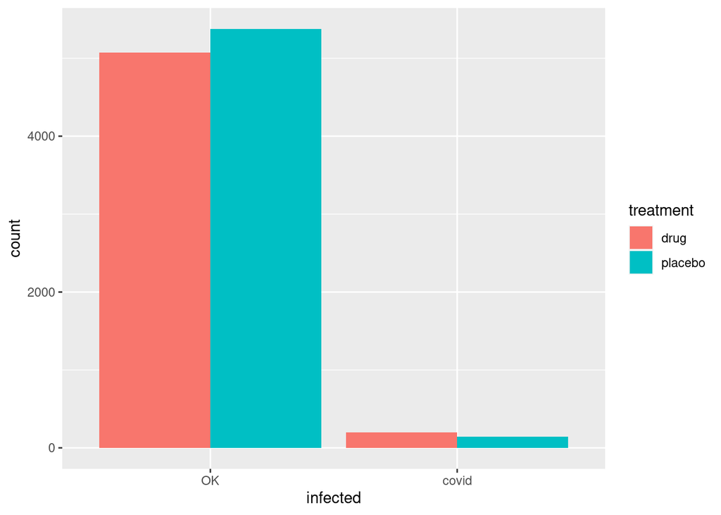

```r
# the group_by followed by summarize(count=n())

basicC <- ggplot(Males,aes(x=infected,y=count,fill=treatment))
basicC + geom_bar(stat="identity",position="dodge")
```

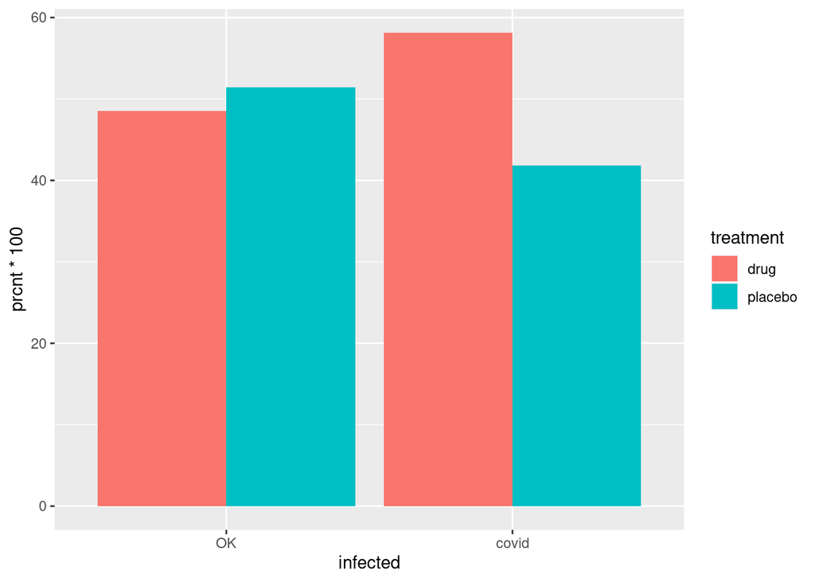

```r
#Now for percentage plot

basicCC <- ggplot(Males,aes(x=infected,y=prcnt*100,fill=treatment))
basicCC + geom_bar(stat="identity", position = "dodge")
```

## 2.2 Numerical Summary

```r
table1 <- xtabs(~treatment + infected, data=Maledata)
rowPerc(table1)
```

```
##          infected
## treatment     OK  covid  Total
##   drug     96.28   3.72 100.00
##   placebo  97.45   2.55 100.00
```

```r
colPerc(table1)
```

```
##          infected
## treatment     OK  covid
##   drug     48.54  58.16
##   placebo  51.46  41.84
##   Total   100.00 100.00
```

```r
print(table1)
```

```
##          infected
## treatment   OK covid
##   drug    5072   196
##   placebo 5378   141
```

## 2.3 Inferential Results

```r
chisq.test(table1)
```

```
##
##  Pearson's Chi-squared test with Yates' continuity correction
##
## data:  table1
## X-squared = 11.721, df = 1, p-value = 0.0006181
```

```r
chisqtestGC(table1)
```

```
## Pearson's Chi-squared test with Yates' continuity correction
##
## Observed Counts:
##          infected
## treatment   OK covid
##   drug    5072   196
##   placebo 5378   141
##
## Counts Expected by Null:
##          infected
## treatment      OK  covid
##   drug    5103.42 164.58
##   placebo 5346.58 172.42
##
## Contributions to the chi-square statistic:
##          infected
## treatment   OK covid
##   drug    0.19  6.00
##   placebo 0.18  5.73
##
##
## Chi-Square Statistic = 11.7206
## Degrees of Freedom of the table = 1
## P-Value = 6e-04
```

```r
fisher.test(table1)
```

```
##
##  Fisher's Exact Test for Count Data
##
## data:  table1
## p-value = 0.0005801
## alternative hypothesis: true odds ratio is not equal to 1
## 95 percent confidence interval:
##  0.5406079 0.8497815
## sample estimates:
## odds ratio
##  0.6784848
```

$H_0$ The null hypothesis explains that the vaccine does not make a difference on infection rate if a male decides to take the vaccine.  
$H_A$ The alternative hypothesis states that their is a difference in infection rate if a male decides to take the vaccine.

# 3 Females

```r
Femaledata<- filter(FinalData,sex=="gal")
Femaledata$sex<- as.factor(Femaledata$sex)
Femaledata$infected=factor(Femaledata$infected)
Femaledata$infected <- relevel(Femaledata$infected, "OK")
levels(Femaledata$infected)
```

```
## [1] "OK"    "covid"
```

## 3.1 Bar Chart

```r
Females <- Femaledata %>% group_by(infected, treatment) %>% summarize(count=n()) %>% mutate(prcnt=count/sum(count))
```

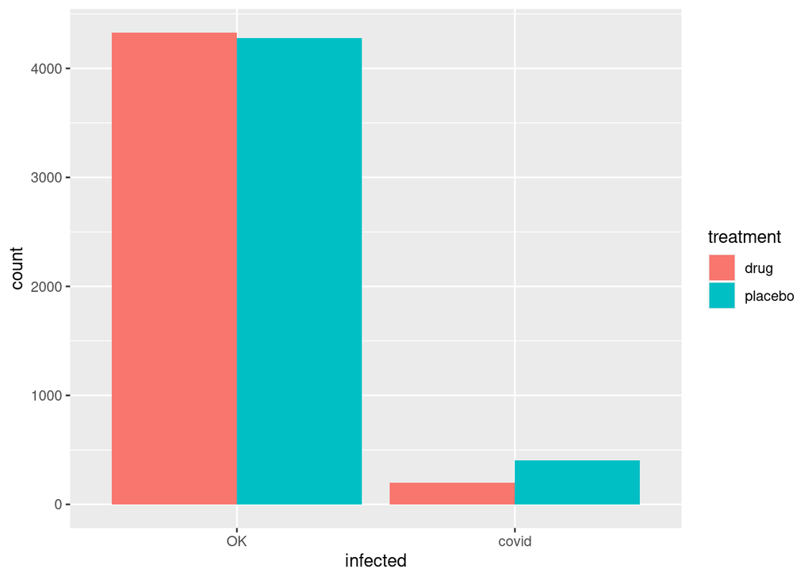

```r
# the group_by followed by summarize(count=n())

basicC <- ggplot(Females,aes(x=infected,y=count,fill=treatment))
basicC + geom_bar(stat="identity",position="dodge")
```

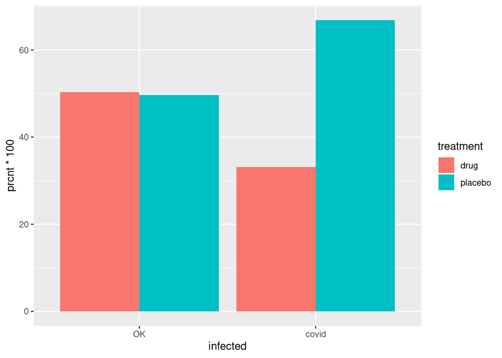

```r
#Now for percentage plot

basicCC <- ggplot(Females,aes(x=infected,y=prcnt*100,fill=treatment))
basicCC + geom_bar(stat="identity", position = "dodge")
```

The Bar Chart shows that approximately out of 607 females infected with covid-91, 32% were given the vaccine and 66% were given the placebo. The Vaccine may be effective on females.

## 3.2 Numerical Summary

```r
table2 <- xtabs(~infected + treatment, data=Femaledata)
rowPerc(table2)
```

```
##         treatment
## infected   drug placebo  Total
##    OK     50.31   49.69 100.00
##    covid  33.11   66.89 100.00
```

```r
colPerc(table2)
```

```
##         treatment
## infected   drug placebo
##    OK     95.56   91.33
##    covid   4.44    8.67
##    Total 100.00  100.00
```

```r
print(table2)
```

```
##         treatment
## infected drug placebo
##    OK    4330    4276
##    covid  201     406
```

## 3.3 Inferential Results

```r
chisq.test(table2)
```

```
##
##  Pearson's Chi-squared test with Yates' continuity correction
##
## data:  table2
## X-squared = 66.43, df = 1, p-value = 3.626e-16
```

```r
chisqtestGC(table2)
```

```
## Pearson's Chi-squared test with Yates' continuity correction
##
## Observed Counts:
##         treatment
## infected drug placebo
##    OK    4330    4276
##    covid  201     406
##
## Counts Expected by Null:
##         treatment
## infected    drug placebo
##    OK    4232.47 4373.53
##    covid  298.53  308.47
##
## Contributions to the chi-square statistic:
##         treatment
## infected  drug placebo
##    OK     2.25    2.17
##    covid 31.86   30.83
##
##
## Chi-Square Statistic = 66.4295
## Degrees of Freedom of the table = 1
## P-Value = 0
```

```r
fisher.test(table2)
```

```
##
##  Fisher's Exact Test for Count Data
##
## data:  table2
## p-value < 2.2e-16
## alternative hypothesis: true odds ratio is not equal to 1
## 95 percent confidence interval:
##  1.713470 2.447107
## sample estimates:
## odds ratio
##   2.045239
```

The Chi Squared table show us that the p value is so small it scour by chance.

We reject the null hypothesis as the vaccine is 67% effective on females.

# 4 LGBTQ

```r
LGBTQdata<- filter(FinalData,LGBTQ=="gay")
LGBTQdata$LGBTQ<- as.factor(LGBTQdata$LGBTQ)
LGBTQdata$infected=factor(LGBTQdata$infected)
LGBTQdata$infected <- relevel(LGBTQdata$infected, "OK")
```

## 4.1 Bar Charts

```r
LGBTQ <- LGBTQdata %>% group_by(infected, treatment) %>% summarize(count=n()) %>% mutate(prcnt=count/sum(count))
```

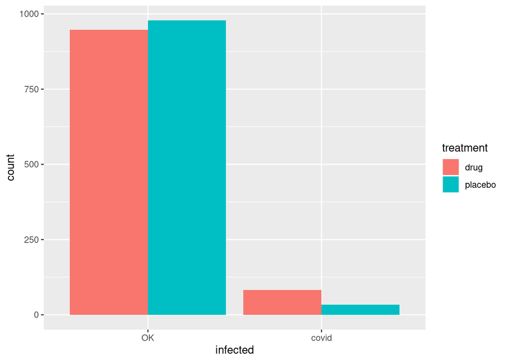

```r
# the group_by followed by summarize(count=n())

basicC <- ggplot(LGBTQ,aes(x=infected,y=count,fill=treatment))
basicC + geom_bar(stat="identity",position="dodge")
```

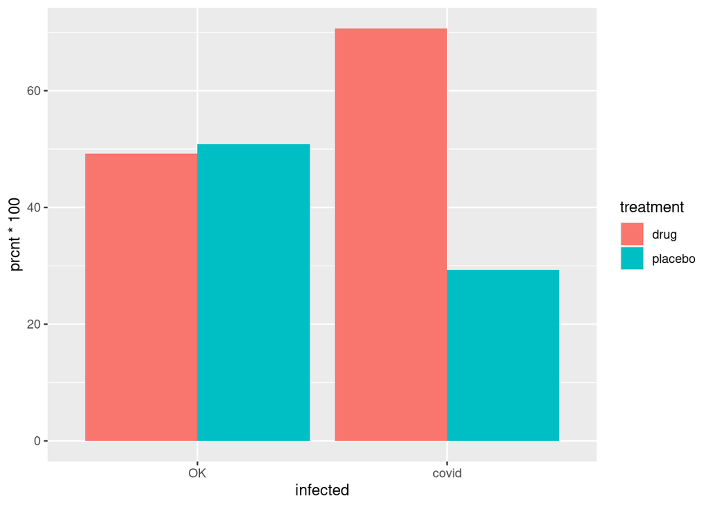

```r
#Now for percentage plot

basicCC <- ggplot(LGBTQ,aes(x=infected,y=prcnt*100,fill=treatment))
basicCC + geom_bar(stat="identity", position = "dodge")
```

From what we can determined from the bar chart out of 116 people who contracted covid about 70% were given the Covid vaccine. We can conclude that the vaccine may not be effective for LGBTQ community.

## 4.2 Numerical Summary

```r
table3 <- xtabs(~infected + treatment, data=LGBTQdata)
rowPerc(table3)
```

```
##         treatment
## infected   drug placebo  Total
##    OK     49.17   50.83 100.00
##    covid  70.69   29.31 100.00
```

```r
colPerc(table3)
```

```
##         treatment
## infected   drug placebo
##    OK     92.03   96.64
##    covid   7.97    3.36
##    Total 100.00  100.00
```

```r
print(table3)
```

```
##         treatment
## infected drug placebo
##    OK     947     979
##    covid   82      34
```

From the table, we can see that 116 LGBTQ members were infected with covid which 70% were given the vaccine. Compared to the 30% who received the placebo.

## 4.3 Inferential Results

```r
chisq.test(table3)
```

```
##
##  Pearson's Chi-squared test with Yates' continuity correction
##
## data:  table3
## X-squared = 19.418, df = 1, p-value = 1.05e-05
```

```r
chisqtestGC(table3)
```

```
## Pearson's Chi-squared test with Yates' continuity correction
##
## Observed Counts:
##         treatment
## infected drug placebo
##    OK     947     979
##    covid   82      34
##
## Counts Expected by Null:
##         treatment
## infected   drug placebo
##    OK    970.55  955.45
##    covid  58.45   57.55
##
## Contributions to the chi-square statistic:
##         treatment
## infected drug placebo
##    OK    0.57    0.58
##    covid 9.48    9.63
##
##
## Chi-Square Statistic = 19.4179
## Degrees of Freedom of the table = 1
## P-Value = 0
```

```r
fisher.test(table3)
```

```
##
##  Fisher's Exact Test for Count Data
##
## data:  table3
## p-value = 5.741e-06
## alternative hypothesis: true odds ratio is not equal to 1
## 95 percent confidence interval:
##  0.2580733 0.6121070
## sample estimates:
## odds ratio
##  0.4012509
```

From the Chi-squared table we can see that the p value is so small that is unlikely that it occur by chance.

$H_0$ The null hypothesis explains that the vaccine has no effect in infection rate on LGBTQ who took the vaccine.  
$H_A$ The alternative hypothesis states that their is a difference in infection rate if a LGBTQ decides to take the vaccine.

The vaccine is 29% effective on the LGBTQ community.

# 5 Drug Users

```r
Druggiedata<- filter(FinalData,DrugUser=="yes")
Druggiedata$DrugUser<- as.factor(Druggiedata$DrugUser)
Druggiedata$infected=factor(Druggiedata$infected)
Druggiedata$infected <- relevel(Druggiedata$infected, "OK")
```

## 5.1 Bar Charts

```r
Druggies <- Druggiedata %>% group_by(infected, treatment) %>% summarize(count=n()) %>% mutate(prcnt=count/sum(count))
```

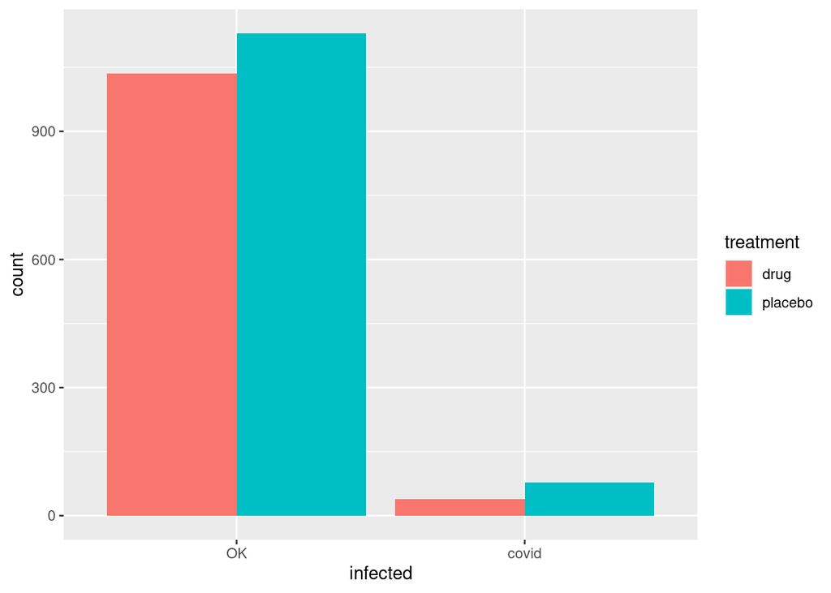

```r
# the group_by followed by summarize(count=n())

basicC <- ggplot(Druggies,aes(x=infected,y=count,fill=treatment))
basicC + geom_bar(stat="identity",position="dodge")
```

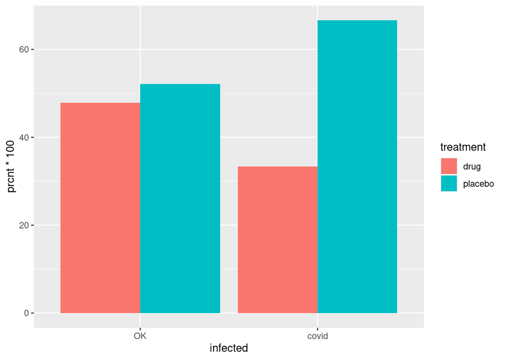

```r
#Now for percentage plot

basicCC <- ggplot(Druggies,aes(x=infected,y=prcnt*100,fill=treatment))
basicCC + geom_bar(stat="identity", position = "dodge")
```

From the Bar Chart approximately we see 117 infected drug users which 32% were given the vaccine.

## 5.2 Numerical Summary

```r
table4 <- xtabs(~infected + treatment, data=Druggiedata)
rowPerc(table4)
```

```
##         treatment
## infected   drug placebo  Total
##    OK     47.83   52.17 100.00
##    covid  33.33   66.67 100.00
```

```r
colPerc(table4)
```

```
##         treatment
## infected   drug placebo
##    OK     96.37   93.54
##    covid   3.63    6.46
##    Total 100.00  100.00
```

```r
print(table4)
```

```
##         treatment
## infected drug placebo
##    OK    1036    1130
##    covid   39      78
```

## 5.3 Inferential Results

```r
chisq.test(table4)
```

```
##
##  Pearson's Chi-squared test with Yates' continuity correction
##
## data:  table4
## X-squared = 8.7902, df = 1, p-value = 0.003028
```

```r
chisqtestGC(table4)
```

```
## Pearson's Chi-squared test with Yates' continuity correction
##
## Observed Counts:
##         treatment
## infected drug placebo
##    OK    1036    1130
##    covid   39      78
##
## Counts Expected by Null:
##         treatment
## infected    drug placebo
##    OK    1019.91 1146.09
##    covid   55.09   61.91
##
## Contributions to the chi-square statistic:
##         treatment
## infected drug placebo
##    OK    0.25    0.23
##    covid 4.70    4.18
##
##
## Chi-Square Statistic = 8.7902
## Degrees of Freedom of the table = 1
## P-Value = 0.003
```

```r
fisher.test(table4)
```

```
##
##  Fisher's Exact Test for Count Data
##
## data:  table4
## p-value = 0.002273
## alternative hypothesis: true odds ratio is not equal to 1
## 95 percent confidence interval:
##  1.220336 2.792730
## sample estimates:
## odds ratio
##   1.833149
```

From the Chi Squared table we can see that the p value is so small that the results are highly unlikely to occur by chance.

$H_0$ The null hypothesis explains that the vaccine has no effect in infection rate on Drug users who took the vaccine.  
$H_A$ The alternative hypothesis states that their is a difference in infection rate if a Drug users decides to take the vaccine.

# 6 Discussion and Conclusion